# Final Project

### Calculate phase angle

Phase angle($\varphi$) is calculated using the below equation along each data point and unwrapped to correct discontinuities occurred during angle computation.

$$\varphi = \tan^{-1}(\frac{\omega}{\theta })$$

```r
phase_angle <- phase_portrait %>%
  select(-phase_portrait) %>%
  unnest() %>%
  select(id, trial, joint, norm_angle, norm_velocity) %>%
  group_by(id, trial, joint) %>%
  nest() %>%
  mutate(phase_angle = map(data, function(data){

     tibble(frame = seq(1, 101, 1),
            phase_angle = signal::unwrap((atan2(data$norm_velocity, data$norm_angle))) * 180 / pi)

  })) %>%
  select(-data) %>%
  unnest()


head(phase_angle)
```

```
## # A tibble: 6 x 5
##   id    trial joint frame phase_angle
##   <fct> <fct> <fct> <dbl>       <dbl>
## 1 1     1     ankle     1        166.
## 2 1     1     ankle     2        159.
## 3 1     1     ankle     3        150.
## 4 1     1     ankle     4        142.
## 5 1     1     ankle     5        136.
## 6 1     1     ankle     6        132.
```

### Plot time-series phase angle plot

```r
phase_angle_plot <- phase_angle %>%
  group_by(id) %>%
  nest() %>%
  mutate(phase_angle_plot = map2(id, data, function(id, data){

    data %>%
      ggplot(aes(x = frame, y = phase_angle, color = trial)) +
      geom_point() +
      scale_color_OkabeIto() +
      facet_wrap(~joint) +
      labs(title = "Phase Angle of Joint During A Gait Cycle",
           subtitle = glue("Subjet #{id}"),
           y = "Phase Angle",
           x = "% of Gait Cycle")
  }))



head(phase_angle_plot)
```

```
## # A tibble: 5 x 3
##   id    data                 phase_angle_plot
##   <fct> <list>               <list>
## 1 1     <tibble [1,515 × 4]> <S3: gg>
## 2 2     <tibble [1,515 × 4]> <S3: gg>
## 3 5     <tibble [1,515 × 4]> <S3: gg>
## 4 6     <tibble [1,515 × 4]> <S3: gg>
## 5 7     <tibble [1,212 × 4]> <S3: gg>
```

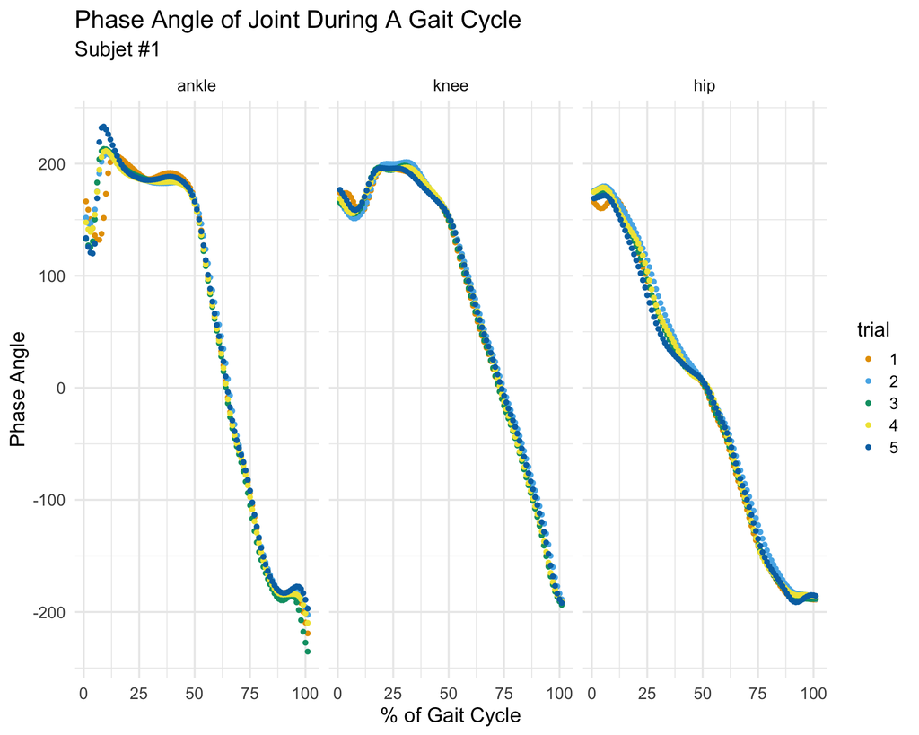

```r
phase_angle_plot$phase_angle_plot[[1]] ## example plot
```

### Calculate hip-knee CRP

CRP is obtained by subtracting the phase angles of distal joint from that of proximal joint as follows. CRP identifies the coordination between two adjacent joints.

$$CRP_{hip\cdot knee}=\varphi_{hip} - \varphi_{knee}$$

```r
crp_hipknee <- phase_angle %>%
  filter(joint == "hip" | joint == "knee") %>%
  spread(joint, phase_angle) %>%
  mutate(crp_hipknee = hip - knee)


head(crp_hipknee)
```

```
## # A tibble: 6 x 6
##   id    trial frame  knee   hip crp_hipknee
##   <fct> <fct> <dbl> <dbl> <dbl>       <dbl>
## 1 1     1         1  174.  166.       -8.27
## 2 1     1         2  174.  163.      -10.4
## 3 1     1         3  174.  161.      -12.6
## 4 1     1         4  174.  160.      -13.6
## 5 1     1         5  173.  160.      -12.2
## 6 1     1         6  170.  162.       -7.85
```

```r
crp_hipknee_plot <- crp_hipknee %>%
  group_by(id) %>%
  nest() %>%
  mutate(crp_hipknee_plot = pmap(list(id, data),
                                 function(id, data){
    data %>%
      ggplot(aes(x = frame, y = crp_hipknee, color = trial)) +
      geom_point() +
      geom_path() +
      scale_color_OkabeIto() +
      labs(title = "Hip-Knee Continuous Relative Phase During A Gait Cycle",
           subtitle = glue("Subject #{id}"),
           y = "CRP",
           x = "% of Gait Cycle")

  }))


head(crp_hipknee_plot)
```

```
## # A tibble: 5 x 3
##   id    data               crp_hipknee_plot
##   <fct> <list>             <list>
## 1 1     <tibble [505 × 5]> <S3: gg>
## 2 2     <tibble [505 × 5]> <S3: gg>
## 3 5     <tibble [505 × 5]> <S3: gg>
## 4 6     <tibble [505 × 5]> <S3: gg>
## 5 7     <tibble [404 × 5]> <S3: gg>
```

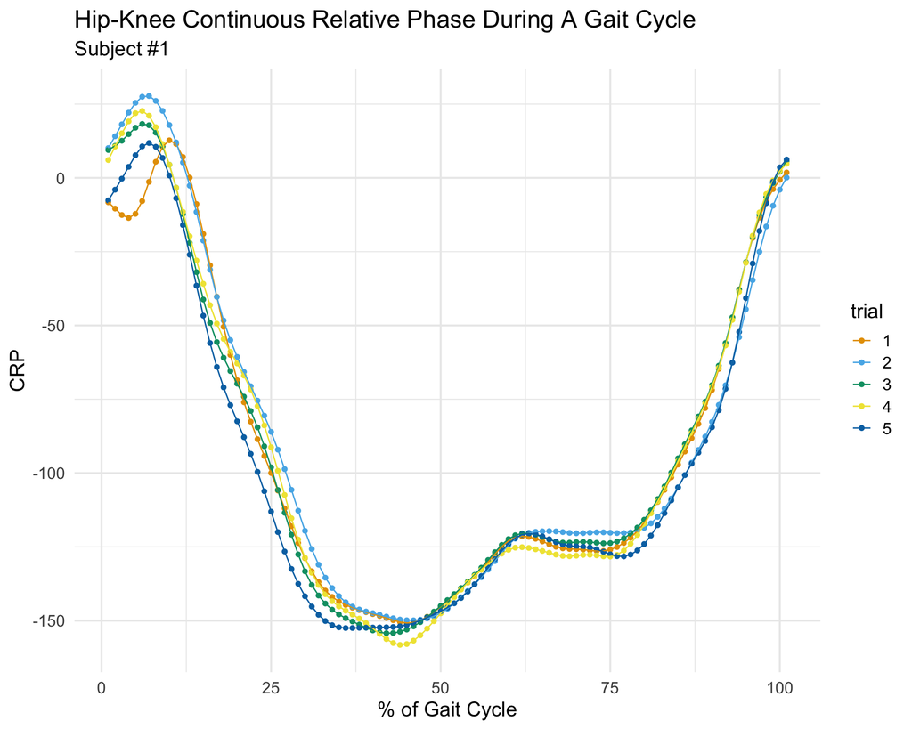

```r
crp_hipknee_plot$crp_hipknee_plot[[1]] ## example plot
```

### Calculate knee-ankle CRP

Similarly, knee-ankle CRP is obtained using the following eqution:

$$CRP_{knee\cdot ankle}=\varphi_{knee} - \varphi_{ankle}$$

```r
crp_kneeankle <- phase_angle %>%
  filter(joint == "knee" | joint == "ankle") %>%
  spread(joint, phase_angle) %>%
  mutate(crp_kneeankle = knee - ankle)

head(crp_kneeankle)
```

```
## # A tibble: 6 x 6
##   id    trial frame ankle  knee crp_kneeankle
##   <fct> <fct> <dbl> <dbl> <dbl>         <dbl>
## 1 1     1         1  166.  174.          7.62
## 2 1     1         2  159.  174.         14.6
## 3 1     1         3  150.  174.         23.3
## 4 1     1         4  142.  174.         31.4
## 5 1     1         5  136.  173.         36.7
## 6 1     1         6  132.  170.         37.7
```

```r
crp_kneeankle_plot <- crp_kneeankle %>%
  group_by(id) %>%
  nest() %>%
  mutate(crp_kneeankle_plot = pmap(list(id, data),
                                   function(id, data){
    data %>%
      ggplot(aes(x = frame, y = crp_kneeankle, color = trial)) +
      geom_point() +
      geom_path() +
      scale_color_OkabeIto() +
      labs(title = "Knee-Ankle Continuous Relative Phase During A Gait Cycle",
           subtitle = glue("Subject #{id}"),
           y = "CRP",
           x = "% of Gait Cycle")

  }))

head(crp_kneeankle_plot)
```

```
## # A tibble: 5 x 3
##   id    data               crp_kneeankle_plot
##   <fct> <list>             <list>
## 1 1     <tibble [505 × 5]> <S3: gg>
## 2 2     <tibble [505 × 5]> <S3: gg>
## 3 5     <tibble [505 × 5]> <S3: gg>
## 4 6     <tibble [505 × 5]> <S3: gg>
## 5 7     <tibble [404 × 5]> <S3: gg>
```

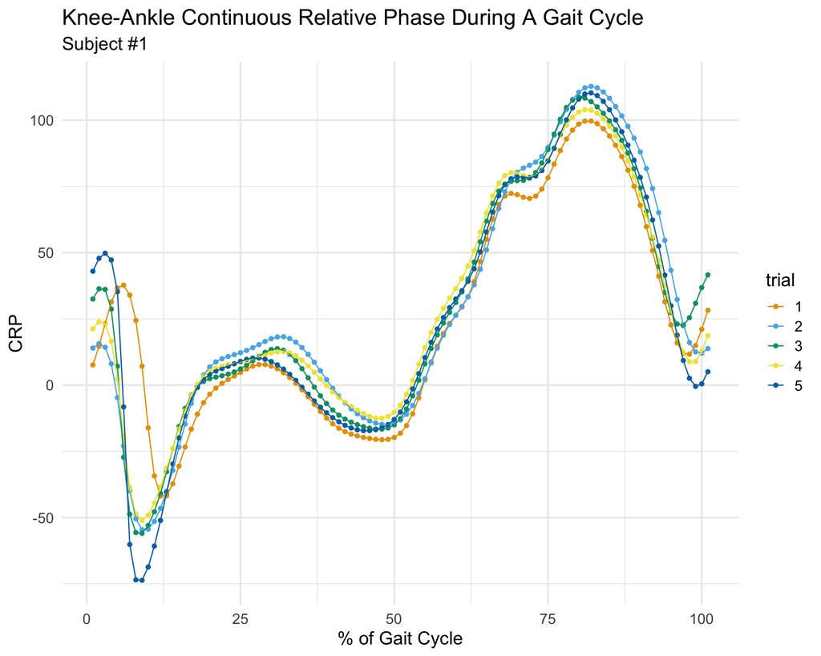

```r
crp_kneeankle_plot$crp_kneeankle_plot[[1]]  ## example plot
```

### Calculate DP

DP is the average value of all standard deviations calculated for each data point over a walking cycle from upto five CRP curves as follows.

$$mean(std(CRP_{i}))$$

```r
dp <- crp_hipknee %>%
  left_join(crp_kneeankle) %>%
  group_by(id, frame) %>%
  summarise(crp_hipknee_sd = sd(crp_hipknee),
            crp_kneeankle_sd = sd(crp_kneeankle)) %>%
  group_by(id) %>%
  summarise(dp_hipknee = mean(crp_hipknee_sd),
            dp_kneeankle = mean(crp_kneeankle_sd))

dp %>%
  mutate(`Deviation Phase:Hip-Knee` = dp_hipknee,
         `Deviation Phase:Knee-Ankle` = dp_kneeankle) %>%
  select(-dp_hipknee, -dp_kneeankle) %>%
  DT::datatable()
```

|  | id | Deviation Phase:Hip-Knee | Deviation Phase:Knee-Ankle |
| --- | --- | --- | --- |
| 1 | 1 | 5.57312501338143 | 7.08560195310302 |
| 2 | 2 | 4.25632687294125 | 10.466476947552 |
| 3 | 5 | 4.5114897500119 | 8.41362332415128 |
| 4 | 6 | 5.73979427254931 | 12.4613165969765 |
| 5 | 7 | 208.391018961684 | 189.150411336182 |

## To do list:

1. Combine plots from **phase_protrait**, **phase_angle_plot**, **crp_hipknee_plot**, **crp_kneeankle_plot**
2. Lauch a Shiny dashboard